# Lab Exercise Sampling

Jyotishka Datta

2020-09-18

## Problem 1

- We’ll see that change of variable often helps with difficult sampling problems. Suppose you have a random variable $X$ with the following density function with an unknown normalizing constant:
  $$f(x) = \exp\{-x^6/10\} \; \text{ where } x \in (0, \infty)$$
  How do we sample from this density?
- Let’s look at a general density of this class with parameters $k$ and $n$:
  $$f(x) \propto \exp\{-k x^{n}\}, \; \text{ where } x \in (0, \infty), k > 0, n > 0.$$
  Show that the transformed variable $Y = X^{n}$ is a Gamma random variable with shape = $1/n$ and rate = $k$, following the steps outlined below:
1. Show that under the transformation $x = y^{1/n}$, the transformed density will be:
   $$f(y) \propto y^{\frac{1}{n}-1} \exp\{-k y\} \; \text{ where } y \in (0, \infty)$$
2. Now, compare the density of $y$ with the Gamma density function with shape parameter $\alpha$ and rate parameter $\lambda$:
   $$f(u) = \frac{\lambda^{\alpha} e^{-\lambda u} u^{\alpha - 1}}{\Gamma(\alpha)}, \; u \ge 0$$
   What are your parameters $\alpha$ and $\lambda$?
3. In R, the function for generating $\text{Gamma}(\alpha, \lambda)$ random samples is `rgamma(n, shape = alpha, rate = lambda)`. Generate $10^5$ samples $Y$ from Gamma distribution with $\lambda = 1/10$ and $\alpha =1/6$. This will give you samples from the distribution of $Y$. Then you can get $X$ samples by $X = Y^{1/n}$.

Plot the histogram of $X = Y^{\alpha}$ along with the function $\exp\{-x^6/10\}$ to visually verify your sampler. You can use the following code for plotting (your plot should look like the Fig. 1):

## Solution (Problem 1)

```r
lambda = 1/10
alpha = 1/6
n = 1e5
y = rgamma(n,shape = alpha, rate = lambda)
z = y^alpha
```

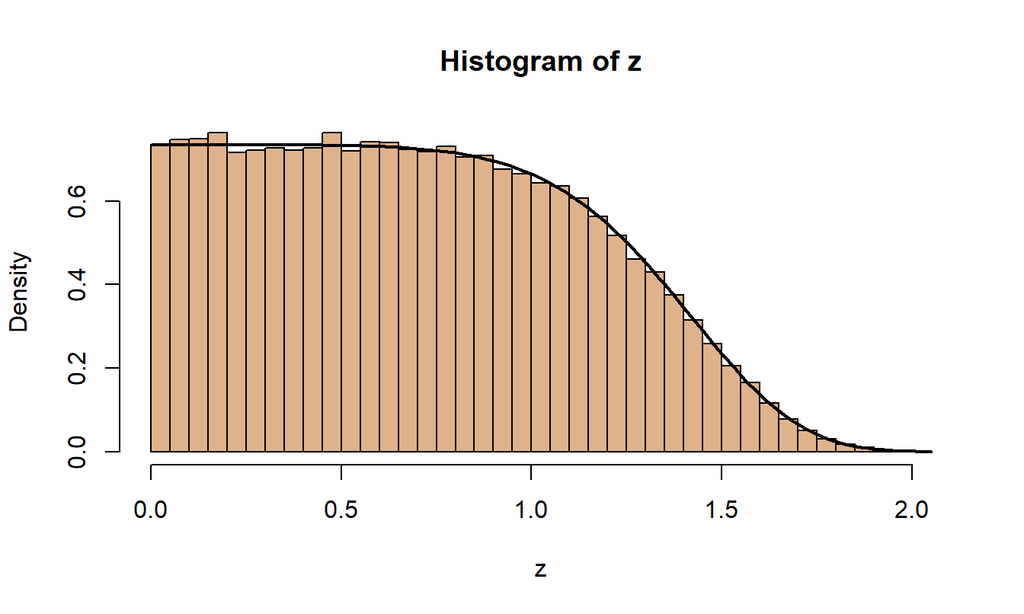

```r
hist(z, breaks = 30, freq = F, col = rgb(0.75,0.4,0.1,0.5)) # z is your sample
lambda = 1/10; alpha = 1/6
target <- function(x){exp(-lambda*x^(1/alpha))/
integrate(function(x) exp(-lambda*x^(1/alpha)),0,Inf)$value}
curve(target,lwd=2,add=T)
```

## Problem 2

A ``truncated" distribution is a distribution where the support of the random variable is restricted to some interval $[a,b]$. If we know the pdf $f(x)$ and cdf $F(x)$ of the original random variable, then the pdf and cdf of the truncated random variable can be easily derived as:
$$f_{Tr}(x) = \begin{cases}
\frac{f(x)}{F(b) - F(a)} \; \forall a < x \le b \\
0 \; \text{otherwise}
\end{cases}$$
Consider the exponential random variable $X \sim \text{Exp}(\lambda)$, with pdf
$$f(x) = \lambda e^{-\lambda x}, \; x \ge 0, \lambda > 0$$

Answer the following:

1. How would you generate from an exponential truncated to the interval $[0,b]$ using accept-reject scheme? Try the R code for $\lambda = 2$, $b = 5$.
2. Can you use the inverse CDF transformation here?

## Solution (Problem 2)

Part 1 is easy. All you have to do is sample from $Exp(\lambda)$ and discard all samples that fall outside the truncation boundary. Also, to generate from exponential we can use the inverse CDF method with
$$F^{-1}(u) = - \frac{1}{\lambda} \log(1-u)$$

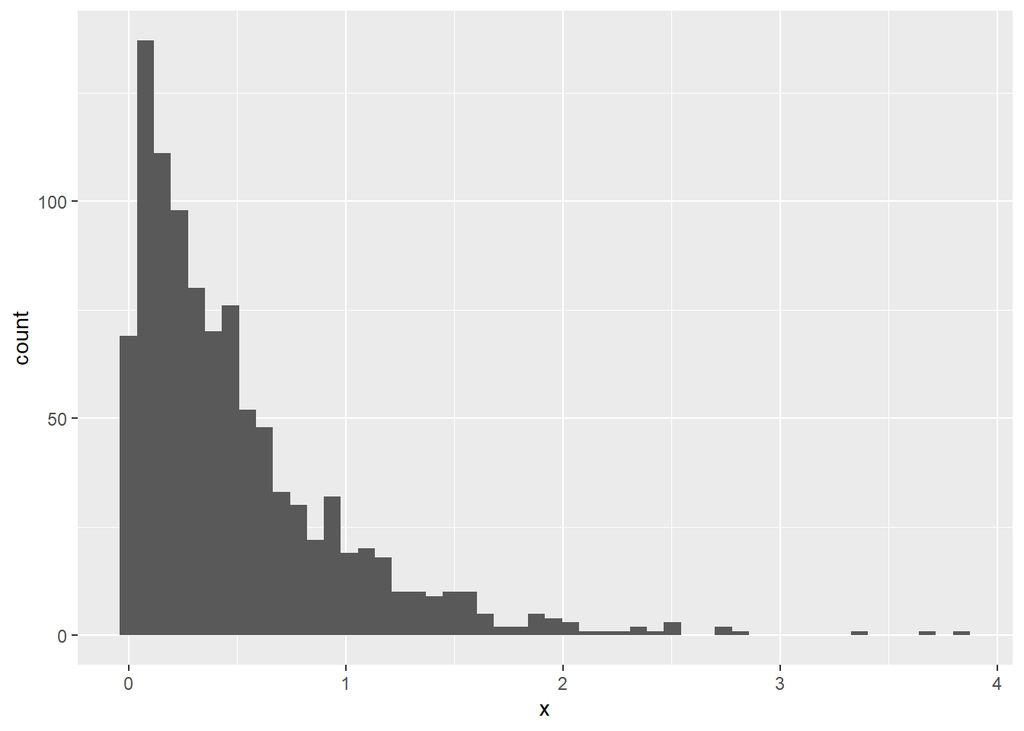

```r
set.seed(123)
n = 1000
u = runif(n)
lambda = 2
a = 0
b = 5

x = (-1/lambda)*log(1-u*(1-exp(-lambda*b)))
## Standard Exponential then truncate
x = -1/lambda*log(u) #u ~ U[0,1] implies 1-u ~ U[0,1]
x = x[x<=b]

## Plotting
library(ggplot2)
ggplot(data.frame(x))+geom_histogram(aes(x=x),bins = 50)
```

Part 2 involves a little math! The pdf of the truncated distribution is given above. We can then calculate the CDF of the truncated exponential:

First the area between $[a,b]$ would be
$$\int_{a}^{b} \lambda e^{-\lambda x} d x = F(b)-F(a) = e^{-\lambda a} - e^{-\lambda b}$$

The CDF for the truncated distribution can be written as:
$$F_{tr}(x) = \frac{F(x)-F(a)}{F(b)-F(a)}, a \le x \le b$$

Since $F(0) = 0$ for exponential, the inverse can be derived by solving the following equation for $x$
$$\text{Solve } u = \frac{F(x)-F(a)}{F(b)-F(a)} = \frac{1- \exp(-\lambda x)}{1- \exp(-\lambda b)} \\
1 - \exp(-\lambda x) = u (1 - \exp(-\lambda b)) \\
x = (-1/\lambda)*\log(1-u (1 - \exp(-\lambda b)))$$
The R code can be written as follows:

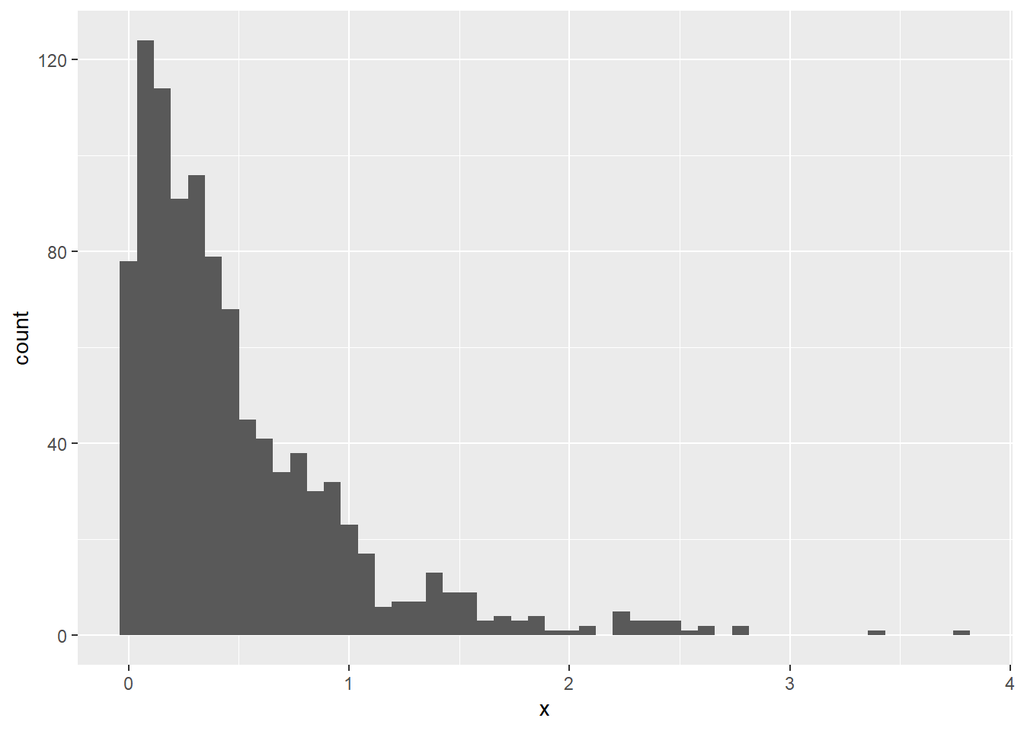

```r
n = 1000
lambda = 2
b = 5
u = runif(n)
x = (-1/lambda)*log(1-u*(1-exp(-lambda*b)))

## Plotting
library(ggplot2)
ggplot(data.frame(x))+geom_histogram(aes(x=x),bins = 50)
```